# Ponte do Brooklyn

O Departamento de Trânsito de NY utilizou formas automatizadas de contar pedestres na Brooklyn Bridge. Para isso, implantou uma câmera no lado de Manhattan da ponte, fazendo a contagem de pedestres no sentido Manhattan, no sentido Brooklyn. Temos também dados de temperatura, chuva, horário e uma coluna de categorização do clima do dia.

Foi contabilizado um total de 11.032.866 pedestres, em um total de 669 dias, em dois períodos: - 2017-10-01 a 2018-07-31 - 2019-01-01 a 2019-12-31

Tivemos uma média de 687 pessoas por hora, uma mediana de 227 pessoas por hora, demonstrando que temos horas em que há uma concentração muito mais alta do que o normal, como por exemplo na hora com mais pedestres, com 4330 no total dos dois sentidos. Tivemos horas também com fluxo zero.

Tivemos uma média de 16.492 pessoas por dia, uma mediana de 16.104 pessoas por dia, demonstrando que temos uma distribuição levemente assimétrica. Temos alguns dias com valores extremos, e dias com nenhum fluxo também, em dias de inverno rigoroso.

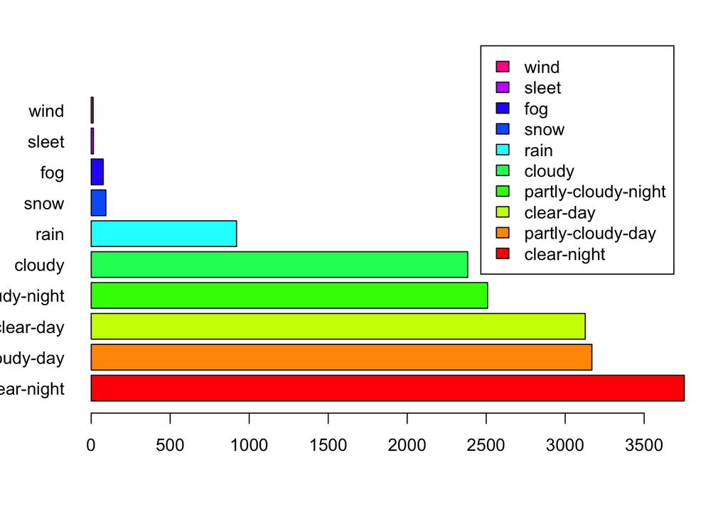

Em relação ao clima, tivemos uma predominância de horas frias e muito frias, somando um total de mais de 60%. Sendo que dias de clima ameno somam 25%. Dias de calor não são comuns em NY. Temos uma temperatura média de 11 graus celsius. A mínima no período apurado foi de -17 graus, e a máxima de 36 graus.

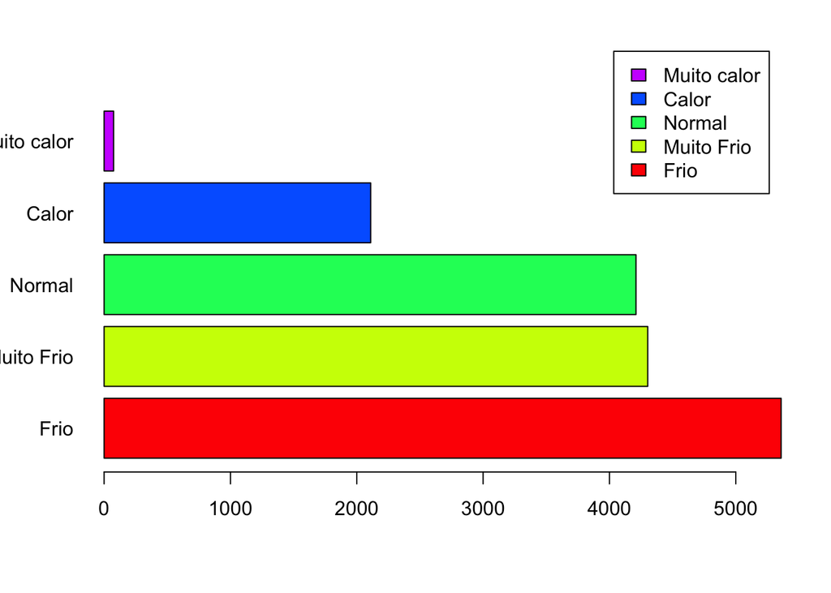

Tivemos 25 datas comemorativas dentro do período análisado. Sendo apenas 7% do total de dias. Não há diferença significativa entre pedestres e dias com ou sem feriado, pois a porcentagem total de pedestres dentro do período analisado para feriados também foi de 7%. Comparando os valores de mediana, 229 para dias sem feriado, e 184 para dias com feriado, mostra que quando tem feriado temos uma concentração menor de pessoas na ponte, tendo alguns picos menos frequentes do que dias normais.

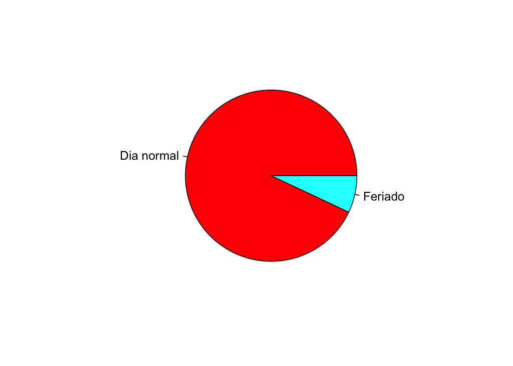

Em relação a finais de semana e dias úteis, temos uma média muito maior nos finais de semana, e com a mediana sendo praticamente igual, temos que os picos de pessoas nos finais de semana são muito mais acentuados do que nos dias de semana.

## Testes de Hipóteses

### Teste 1: A presença de chuva afeta significativamente o número de pedestres?

H0: Com chuva == Sem Chuva

H1: Com chuva != Sem Chuva

Nenhuma das distribuições é normal, então usaremos um teste não paramétrico para 2 distribuições. Para isso usaremos o teste de Wilcoxon.

```
##
##  Wilcoxon rank sum test with continuity correction
##
## data:  Pedestrians by com_chuva
## W = 24043824, p-value = 9.524e-06
## alternative hypothesis: true location shift is not equal to 0
```

Como temos `p-value` < 0.05, rejeitamos H0, demonstrando que temos diferença significativa entre dias de chuva e dias sem chuva.

### Teste 2: A quantidade média de pedestres varia entre estações do ano?

H0: Primavera == Verão == Outono == Inverno

H1: Alguma diferença entre as estações

Nenhuma das distribuições é normal, então usaremos um teste não paramétrico para 4 distribuições. Para isso usaremos o teste de Kruskal-Wallis, seguido do teste complementar.

```
##
##  Kruskal-Wallis rank sum test
##
## data:  Pedestrians by estacao
## Kruskal-Wallis chi-squared = 521.93, df = 3, p-value < 2.2e-16
```

```
##   Kruskal-Wallis rank sum test
##
## data: x and group
## Kruskal-Wallis chi-squared = 521.9326, df = 3, p-value = 0
##
##
##                            Comparison of x by group
##                                  (Bonferroni)
## Col Mean-|
## Row Mean |    Inverno     Outono   Primaver
## ---------+---------------------------------
##   Outono |  -8.175352
##          |    0.0000*
## Primaver |  -18.30809  -9.830392
##          |    0.0000*    0.0000*
##    Verão |  -19.79969  -11.99782  -3.007490
##          |    0.0000*    0.0000*    0.0079*
##
## alpha = 0.05
## Reject Ho if p <= alpha/2
```

Como temos `p-value` < 0.05, rejeitamos H0, demonstrando que temos diferença significativa. Com o teste complementar, temos uma confirmação de que nenhuma estação tem comparação entre si.

### Teste 3: Correlação entre a quantidade de pessoas indo sentido Brooklyn e indo a Manhattan?

H0: Não há correlação

H1: Há correlação

Como estamos lidando com distribuições que não são normais, usaremos o método de `spearman`.

```
##
##  Spearman's rank correlation rho
##
## data:  dados$Towards.Brooklyn and dados$Towards.Manhattan
## S = 3.1273e+10, p-value < 2.2e-16
## alternative hypothesis: true rho is not equal to 0
## sample estimates:
##       rho
## 0.9546766
```

Como temos `p-value` < 0.05, rejeitaremos H0, demonstrando que há correlação entre os fluxos.

### Teste 4: Existe correlação entre temperatura e número de pedestres?

Como estamos lidando com distribuições que não são normais, usaremos o método de `spearman`.

```
##
##  Spearman's rank correlation rho
##
## data:  dados$temperature and dados$Pedestrians
## S = 4.5187e+11, p-value < 2.2e-16
## alternative hypothesis: true rho is not equal to 0
## sample estimates:
##       rho
## 0.3431444
```

Como temos `p-value` < 0.05, rejeitaremos H0, demonstrando que há correlação entre temperatura e fluxo.

### Teste 5: Há diferença significativa entre dias normais e dias com feriados?

H0: Dias normais == Com feriados

H1: Dias normais != Com feriados

Nenhuma das distribuições é normal, então usaremos um teste não paramétrico para 2 distribuições. Para isso usaremos o teste de Wilcoxon.

```
##
##  Wilcoxon rank sum test with continuity correction
##
## data:  Pedestrians by algum_evento
## W = 8512280, p-value = 0.4235
## alternative hypothesis: true location shift is not equal to 0
```

Como temos `p-value` > 0.05, aceitamos H0 indicando que não há diferença significativa entre dias com feriados e dias sem feriados.

### Teste 6: Há diferença significativa entre dias úteis e finais de semana?

H0: Dias úteis == FDS

H1: Dias úteis != FDS

Nenhuma das distribuições é normal, então usaremos um teste não paramétrico para 2 distribuições. Para isso usaremos o teste de Wilcoxon.

```
##
##  Wilcoxon rank sum test with continuity correction
##
## data:  Pedestrians by dia_tipo
## W = 24345704, p-value = 1.754e-13
## alternative hypothesis: true location shift is not equal to 0
```

Como temos `p-value` < 0.05, rejeitaremos H0, demonstrando que há diferença significativa entre dias úteis e fins de semana.

### Teste 7: Quantidade de pessoas indo sentido Brooklyn diferente de indo a Manhattan?

H0: Sentido Brooklyn == Sentido Manhattan

H1: Sentido Brooklyn != Sentido Manhattan

Como estamos lidando com distribuições que não são normais, usaremos o teste pareado de Wilcoxon.

```
##
##  Wilcoxon signed rank test with continuity correction
##
## data:  dados$Towards.Brooklyn and dados$Towards.Manhattan
## V = 59319724, p-value < 2.2e-16
## alternative hypothesis: true location shift is not equal to 0
```

Como temos `p-value` < 0.05, rejeitaremos H0, demonstrando que há diferença entre a diferença de sentidos.